# Individual Tumor Dynamics and Their Link to Survival: Two-Stage and Joint Modeling

Portfolio project — Pharmacometrics-inspired modeling in oncology

Juliette Bouli-Mengue

## 1. Motivation

In oncology drug development, individual tumor size trajectories (typically summarized as Sum of Longest Diameters, SLD, per RECIST criteria) are often linked to survival outcomes (Progression-Free Survival, PFS; Overall Survival, OS) to support dose selection and efficacy predictions. This notebook demonstrates, on **fully simulated data**, two complementary approaches used in pharmacometrics to link tumor dynamics to survival: a classic “two-stage” approach (individual parameter estimation followed by a Cox model), and a joint model (simultaneous estimation of the longitudinal trajectory and survival).

No real patient data is used here. The goal is to demonstrate methodological understanding before applying the same logic to real datasets.

### The Tumor Growth Inhibition (TGI) model

We use a simplified biexponential TGI model inspired by the regression/regrowth framework of Wang et al. (*Clin Pharmacol Ther*, 2009; doi:10.1038/clpt.2009.64), rather than an exact reproduction of that publication:

$$SLD(t) = SLD_0 \times (e^{-g \cdot t} +
e^{d \cdot t} - 1)$$

- **g**: tumor regression rate (treatment effect)
- **d**: tumor regrowth rate (resistance)
- **SLD0**: baseline tumor size

```r
library(minpack.lm)
library(survival)
library(survminer)
library(JM)
library(nlme)
library(dplyr)
library(ggplot2)

project_root <- Sys.getenv("TUMOR_PROJECT_ROOT", unset = "..")
source(file.path(project_root, "R", "config.R"))
source(file.path(project_root, "R", "metrics.R"))
set_project_seed()
```

**Setup check.** The modeling libraries, shared configuration, and metric helpers are loaded from the project rather than duplicated here. The fixed seed makes the simulated population and all downstream comparisons reproducible.

## 2. Simulating “true” individual patient parameters

We simulate 200 patients. Each has their own growth (`g`), regrowth (`d`), and baseline tumor size (`SLD0`), drawn from log-normal distributions to reflect realistic between-patient variability.

```r
n_patients <- 200

g_pop      <- 0.020
omega_g    <- 0.5
d_pop      <- 0.010
omega_d    <- 0.6
SLD0_pop   <- 60
omega_SLD0 <- 0.3

patients <- tibble(
  patient_id = 1:n_patients,
  g    = rlnorm(n_patients, log(g_pop), omega_g),
  d    = rlnorm(n_patients, log(d_pop), omega_d),
  SLD0 = rlnorm(n_patients, log(SLD0_pop), omega_SLD0)
)

head(patients)
```

```
## # A tibble: 6 × 4
##   patient_id      g       d  SLD0
##        <int>  <dbl>   <dbl> <dbl>
## 1          1 0.0397 0.00301  89.6
## 2          2 0.0151 0.0122   46.2
## 3          3 0.0240 0.0202   61.0
## 4          4 0.0274 0.0344   60.9
## 5          5 0.0245 0.00438  50.4
## 6          6 0.0190 0.00501  44.5
```

**Observation.** The table contains one row per patient and preserves the three latent quantities needed downstream: baseline burden, regression rate, and regrowth rate. Their log-normal construction keeps them positive while introducing between-patient heterogeneity.

## 3. Simulating survival outcomes

Survival is simulated using a proportional hazards structure: a higher `g` (better response) protects the patient, while a higher `d` (faster regrowth) increases the hazard.

```r
beta_g <- -15
beta_d <- 20
h0     <- 0.015

patients <- patients %>%
  mutate(
    g_c = g - mean(g),
    d_c = d - mean(d),
    linear_pred = beta_g * g_c + beta_d * d_c,
    hazard = h0 * exp(linear_pred),
    true_event_time = rexp(n(), rate = hazard)
  )

admin_censoring <- 104

patients <- patients %>%
  mutate(
    os_time  = pmin(true_event_time, admin_censoring),
    os_event = as.integer(true_event_time <= admin_censoring)
  )

summary(patients$os_time)
```

```
##     Min.  1st Qu.   Median     Mean  3rd Qu.     Max.
##   0.1309  22.7826  52.3495  54.6773  93.3075 104.0000
```

```r
table(patients$os_event)
```

```
##
##   0   1
##  46 154
```

**Result and decision.** Survival now has an explicit, known data-generating mechanism and administrative censoring at 104 weeks. This ground truth lets the later approaches be assessed on whether they recover a signal that genuinely exists, rather than merely whether they produce a small p-value.

## 4. Simulating longitudinal tumor measurements

Tumor size is measured every 3 weeks over 72 weeks, with 8% multiplicative measurement noise. *This observation design — scan frequency and measurement precision — was chosen deliberately after an earlier, sparser design (6-week scans, 15% noise) failed to recover a significant tumor-dynamics/survival association despite a strong true effect by construction: a textbook case of attenuation by measurement error, where noisy individual parameter estimates dilute a real underlying signal. The design below is the one that successfully recovers the signal.*

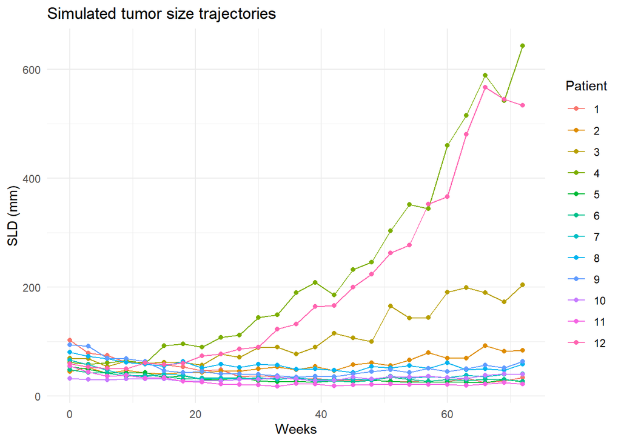

```r
assessment_times <- seq(0, 72, by = 3)
sigma_obs <- 0.08

longitudinal_data <- patients %>%
  rowwise() %>%
  do({
    pt <- .
    tibble(
      patient_id = pt$patient_id,
      time = assessment_times,
      SLD_true = pt$SLD0 * (exp(-pt$g * assessment_times) + exp(pt$d * assessment_times) - 1)
    )
  }) %>%
  ungroup() %>%
  mutate(SLD_obs = SLD_true * exp(rnorm(n(), 0, sigma_obs))) %>%
  filter(SLD_obs > 0)

ggplot(longitudinal_data %>% filter(patient_id <= 12),
       aes(x = time, y = SLD_obs, group = patient_id, color = factor(patient_id))) +
  geom_line() + geom_point() +
  labs(title = "Simulated tumor size trajectories", x = "Weeks", y = "SLD (mm)", color = "Patient") +
  theme_minimal()
```

**Observation.** The trajectories display heterogeneous regression and regrowth around the underlying smooth curves. The three-week schedule and 8% noise level are retained because they preserve enough information to estimate individual dynamics; the earlier sparse/noisy design remains documented above as an informative failed sensitivity analysis.

## 5. Two-stage approach: re-estimating g and d from noisy scans

We act as if the true `g` and `d` were unknown, and re-estimate them for each patient from their noisy longitudinal measurements only.

```r
fit_one_patient <- function(df) {
  tryCatch({
    fit <- nlsLM(
      SLD_obs ~ SLD0_est * (exp(-g_est * time) + exp(d_est * time) - 1),
      data = df,
      start = list(SLD0_est = df$SLD_obs[df$time == 0][1], g_est = 0.02, d_est = 0.01),
      lower = c(SLD0_est = 1, g_est = 0.0001, d_est = 0.0001),
      upper = c(SLD0_est = 500, g_est = 1, d_est = 1),
      control = nls.lm.control(maxiter = 200)
    )
    coefs <- coef(fit)
    tibble(g_hat = coefs["g_est"], d_hat = coefs["d_est"], convergence = TRUE)
  }, error = function(e) {
    tibble(g_hat = NA_real_, d_hat = NA_real_, convergence = FALSE)
  })
}

individual_fits <- longitudinal_data %>%
  group_by(patient_id) %>%
  filter(n() >= 4) %>%
  group_modify(~ fit_one_patient(.x)) %>%
  ungroup()

cat("Convergence rate:", mean(individual_fits$convergence, na.rm = TRUE) * 100, "%\n")
```

```
## Convergence rate: 100 %
```

```r
analysis_data <- patients %>%
  inner_join(individual_fits, by = "patient_id") %>%
  filter(convergence, !is.na(g_hat), !is.na(d_hat))

cox_model <- coxph(Surv(os_time, os_event) ~ g_hat + d_hat, data = analysis_data)
summary(cox_model)
```

```
## Call:
## coxph(formula = Surv(os_time, os_event) ~ g_hat + d_hat, data = analysis_data)
##
##   n= 200, number of events= 154
##
##             coef  exp(coef)   se(coef)      z Pr(>|z|)
## g_hat -1.414e+01  7.197e-07  6.256e+00 -2.261  0.02377 *
## d_hat  2.860e+01  2.641e+12  8.974e+00  3.187  0.00144 **
## ---
## Signif. codes:  0 '***' 0.001 '**' 0.01 '*' 0.05 '.' 0.1 ' ' 1
##
##       exp(coef) exp(-coef) lower .95 upper .95
## g_hat 7.197e-07  1.389e+06 3.403e-12 1.522e-01
## d_hat 2.641e+12  3.787e-13 6.065e+04 1.150e+20
##
## Concordance= 0.604  (se = 0.023 )
## Likelihood ratio test= 13.99  on 2 df,   p=9e-04
## Wald test            = 15.82  on 2 df,   p=4e-04
## Score (logrank) test = 15.78  on 2 df,   p=4e-04
```

```r
cor_g <- cor(analysis_data$g, analysis_data$g_hat)
cor_d <- cor(analysis_data$d, analysis_data$d_hat)
cor_g
```

```
## [1] 0.9048176
```

```r
correlation_ci(cor_g, nrow(analysis_data))
```

```
##     lower     upper
## 0.8760520 0.9271665
```

```r
cor_d
```

```
## [1] 0.9945413
```

```r
correlation_ci(cor_d, nrow(analysis_data))
```

```
##     lower     upper
## 0.9927890 0.9958687
```

**Quality check.** Convergence is reported before the survival model so that selection caused by failed individual fits remains visible. Correlations against the hidden true parameters assess recovery directly, while the Cox model tests whether the estimated dynamics retain their prognostic signal.

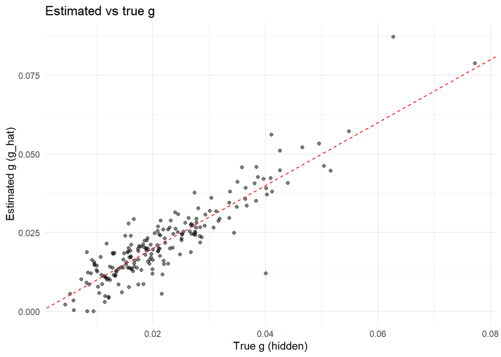

```r
ggplot(analysis_data, aes(x = g, y = g_hat)) +
  geom_point(alpha = 0.5) +
  geom_abline(slope = 1, intercept = 0, color = "red", linetype = "dashed") +
  labs(title = "Estimated vs true g", x = "True g (hidden)", y = "Estimated g (g_hat)") +
  theme_minimal()
```

**Visual check.** The identity line is stricter than correlation alone: it can reveal systematic bias as well as ranking agreement. The close alignment is consistent with the high numerical recovery reported below.

**Interpretation.** `g_hat` and `d_hat` recover the true parameters well (correlations of 0.905 and 0.995 respectively; Fisher 95% CIs 0.876–0.927 and 0.993–0.996). The Cox model detects a significant association between `g_hat` and survival (p = 0.0238), consistent with the true simulated effect (`beta_g = -15`).

The two-stage approach, however, has a structural limitation: it treats parameter estimation and survival modeling as two independent steps, ignoring the uncertainty of `g_hat`/`d_hat` when they are reused as fixed covariates. This motivates the joint modeling approach developed below.

```r
saveRDS(patients, "patients_final.rds")
saveRDS(longitudinal_data, "longitudinal_data_final.rds")
```

**Pipeline output.** The patient-level and longitudinal datasets are saved without dropping their simulated ground truth. They become the reproducible inputs for the PK/PD, multi-lesion, RECIST, PFS, and OS notebooks that follow.

## 6. Joint model: simultaneous estimation

A joint model estimates the longitudinal trajectory and survival simultaneously, sharing information through common random effects, with estimation uncertainty properly propagated into the survival model. Standard R joint modeling packages (`JM`) require a linear (not biexponential) longitudinal submodel; we therefore model `log(SLD)` as a linear function of time — a deliberate, documented simplification.

```r
joint_data <- longitudinal_data %>%
  filter(SLD_obs > 0) %>%
  mutate(log_SLD = log(SLD_obs)) %>%
  inner_join(patients %>% dplyr::select(patient_id, os_time, os_event), by = "patient_id") %>%
  mutate(patient_id = factor(patient_id))

surv_data <- patients %>%
  mutate(patient_id = factor(patient_id)) %>%
  as.data.frame()
```

**Preparation check.** The longitudinal and survival tables use the same factor-valued patient identifier. Positive SLD values are log-transformed for the linear mixed model; the original biexponential measurements remain unchanged in `longitudinal_data`.

```r
fit_lme <- lme(log_SLD ~ time, random = ~ time | patient_id, data = joint_data)

fit_cox <- coxph(Surv(os_time, os_event) ~ 1, data = surv_data, x = TRUE)

fit_joint <- jointModel(fit_lme, fit_cox, timeVar = "time", method = "piecewise-PH-aGH")

summary(fit_joint)
```

```
##
## Call:
## jointModel(lmeObject = fit_lme, survObject = fit_cox, timeVar = "time",
##     method = "piecewise-PH-aGH")
##
## Data Descriptives:
## Longitudinal Process     Event Process
## Number of Observations: 5000 Number of Events: 154 (77%)
## Number of Groups: 200
##
## Joint Model Summary:
## Longitudinal Process: Linear mixed-effects model
## Event Process: Relative risk model with piecewise-constant
##      baseline risk function
## Parameterization: Time-dependent
##
##   log.Lik       AIC       BIC
##  1742.922 -3457.843 -3411.667
##
## Variance Components:
##              StdDev    Corr
## (Intercept)  0.3248  (Intr)
## time         0.0111  0.1028
## Residual     0.1193
##
## Coefficients:
## Longitudinal Process
##              Value Std.Err  z-value p-value
## (Intercept) 3.9121  0.0232 168.6176 <0.0001
## time        0.0060  0.0008   7.5979 <0.0001
##
## Event Process
##             Value  Std.Err z-value p-value
## Assoct     0.2680   0.1315  2.0379  0.0416
## log(xi.1) -5.3953   0.5548 -9.7243
## log(xi.2) -5.4307   0.5644 -9.6212
## log(xi.3) -5.3459   0.5724 -9.3397
## log(xi.4) -5.2883   0.5861 -9.0229
## log(xi.5) -5.3185   0.5979 -8.8957
## log(xi.6) -5.4556   0.6593 -8.2746
## log(xi.7) -4.5768 820.2257 -0.0056
##
## Integration:
## method: (pseudo) adaptive Gauss-Hermite
## quadrature points: 3
##
## Optimization:
## Convergence: 0
```

**Interpretation.** The association parameter (“Assoct”) quantifies the link between the current value of the longitudinal trajectory and the hazard. Here, `Assoct = 0.268` (p = 0.0416): a higher current `log(SLD)` is associated with increased hazard, in the biologically expected direction.

## 7. Two-stage vs. joint model: an honest comparison

| Approach | Signal detected | Model complexity | Trade-off |
| --- | --- | --- | --- |
| Two-stage | Significant (p = 0.0238) on `g_hat` | Rich (two biological rate parameters, g and d) | Ignores estimation uncertainty of g_hat/d_hat |
| Joint model | Significant (p = 0.0416) | Simplified (single linear trend) | Statistically more rigorous, but coarser biological representation |

The joint model is not “worse” — it is more conservative because it properly accounts for trajectory uncertainty, using a deliberately simplified tumor dynamics representation. This is a genuine methodological trade-off: pharmacometricians must balance model realism against statistical tractability and interpretability.

## 8. Conclusion, limitations, and decisions for the next notebooks

This notebook establishes the project’s simulation backbone. Both analyses recover the constructed tumor–survival relationship: the two-stage model retains richer biological parameters, whereas the joint model propagates longitudinal uncertainty at the cost of a simpler trajectory. This is a methodological comparison, not evidence that one framework universally dominates the other.

**Decisions carried forward:**

1. Reuse `patients_final.rds` as the common population so later comparisons differ by modeled mechanisms rather than by newly sampled cohorts.
2. Keep units explicit whenever weekly tumor parameters enter day-level PK/PD models.
3. Preserve untreated counterfactual trajectories so treatment comparisons share the same data-generating structure.
4. Build RECIST progression from longitudinal burden instead of simulating PFS as an unrelated endpoint.

**Limitations:**

- The two-stage approach ignores estimation uncertainty when parameters are reused as fixed covariates; the joint model addresses this but uses a simplified linear tumor trajectory instead of the full biexponential model.
- The association structure used in the joint model is the “current value” parameterization; other parameterizations (current slope, cumulative effects) could be explored and compared.
- Validation on a real dataset (e.g., a public NSCLC trial from Project Data Sphere) would be the natural next step, once methodological understanding is demonstrated on simulated data with known ground truth.